# Visualizando datos con ggplot2 - Parte 1

Daniel Gutierrez

El paquete ggplot fue desarrollado por Hadley Wickham a partir de su tesis doctoral “La gramática de los gráficos”. La gramática proviene de las múltiples capas de un gráfico. Para comenzar, instalar y cargar la libreria ggplot2 (ggplot2 está dentro del tidyverse. Así que puede instalar y cargar el tidyverse que cargará automáticamente ggplot2).

```r
#install.packages{"ggplot2"}
library(ggplot2)
```

Usaremos un conjunto de datos de R (“mtcars”). Es una base de datos con características de diferentes modelos de autos. Consta de datos con 32 observaciones en 11 variables (numéricas), que se describen a continuación:

- mgp: millas/galón (EE. UU.)
- cyl: Número de cilindros
- disp: Desplazamiento (cu.in.)
- hp: potencia bruta
- drat: relación del eje trasero
- wt: Peso (1000 libras)
- qsec: 1/4 de milla hora
- vs: Motor (0 = en forma de V, 1 = recto)
- am: Transmisión (0 = automática, 1 = manual)
- gear: Número de marchas hacia adelante
- carb: Número de carburadores

```r
data("mtcars")
```

Para visualizar las primeras filas del banco, podemos usar el comando head

```r
head(mtcars)
```

```
##                    mpg cyl disp  hp drat    wt  qsec vs am gear carb
## Mazda RX4         21.0   6  160 110 3.90 2.620 16.46  0  1    4    4
## Mazda RX4 Wag     21.0   6  160 110 3.90 2.875 17.02  0  1    4    4
## Datsun 710        22.8   4  108  93 3.85 2.320 18.61  1  1    4    1
## Hornet 4 Drive    21.4   6  258 110 3.08 3.215 19.44  1  0    3    1
## Hornet Sportabout 18.7   8  360 175 3.15 3.440 17.02  0  0    3    2
## Valiant           18.1   6  225 105 2.76 3.460 20.22  1  0    3    1
```

Para construir un gráfico usando ggplot, supongamos que los gráficos están formados por capas(layers).

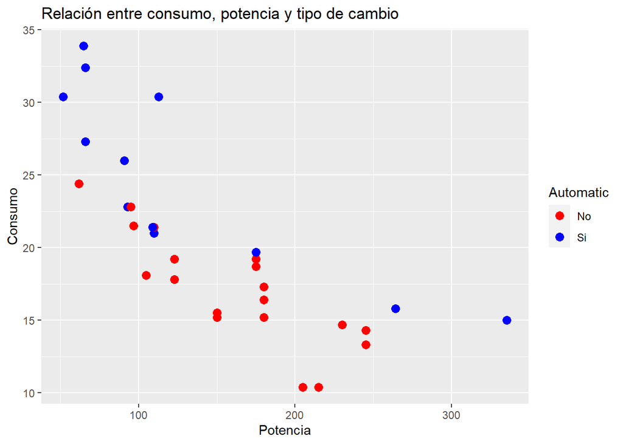

```r
# Iniciamos
g <- ggplot(mtcars)
# Adicionar puntos (geom_point) y
# vamos a mapear variables a elementos estéticos de los puntos.
# Size = 3 define el tamaño de todos los puntos.
g <- g +
geom_point(aes(x = hp, y = mpg, color = factor(am)),
size = 3)
# Alterando la escala de colores
g <- g +
scale_color_manual("Automatic",
values = c("red", "blue"),
labels = c("No", "Si"))
# Títulos
g <- g +
labs(title = 'Relación entre consumo, potencia y tipo de cambio',
y = 'Consumo',
x = 'Potencia')
g
```

Analicemos el código que usamos para hazer el gráfico anterior

Primero, usamos el conjunto de datos por ggplot(mtcars)

Despues, agregamos una capa de puntos, para las variables hp e mpg, con las posiciones en los ejes “x” e “y”. Además, una variable am para el color de cada punto

Luego, alteramos la escala de color, definimos su título, etiquetas (labels) y los valores (values) para los colores. Finalmente, definimos los títulos y etiquetas de los ejes.

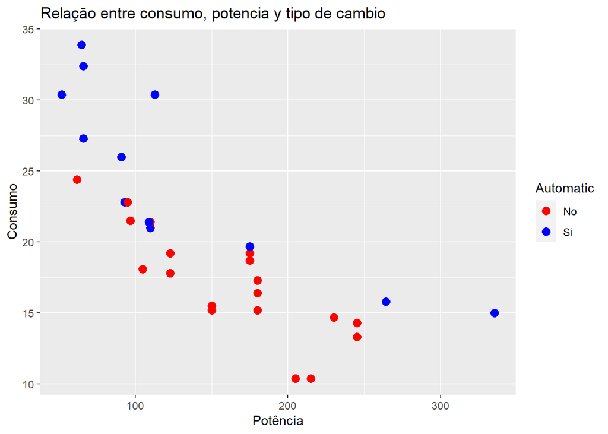

```r
ggplot(mtcars) +
geom_point(aes(x = hp, y = mpg, color = factor(am)),
size = 3) +
scale_color_manual("Automatic",
values = c("red", "blue"),
labels = c("No", "Si")) +
labs(title = 'Relação entre consumo, potencia y tipo de cambio',
y = 'Consumo',
x = 'Potência')
```

Cada gráfico tiene 3 conjuntos de elementos: I) conjunto de datos (data) II) Sistema de coordenadas (mapping) III) conjunto de figuras geométricas que caracterizan el gráfico (geom)

Mapeo Estético son características visuales de los objetos geométricos (puntos, barras, líneas, etc.). Usamos la función aes() para esto. En nuestro ejemplo, usamos 3 características visuales: posición x, posición y y color.

Los objetos geométricos comienzan con la expresión geom_ y serán seguidos por el tipo de objeto. A continuación algunos ejemplos:

- Dispersión: geom_point()
- Barras: geom_bar()
- Histograma: geom_histogram()
- Boxplot: geom_boxplot()
- Densidad: geom_density()
- Lineas: geom_line()

Note que las capas son unidas del signo +

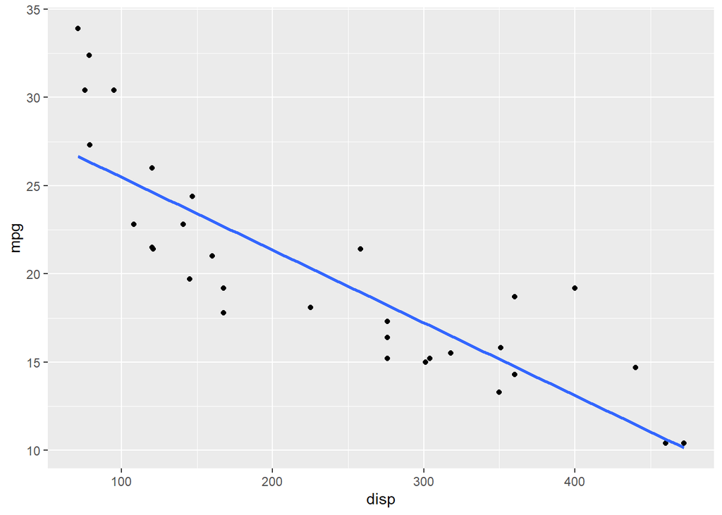

```r
g1 <- ggplot(mtcars, aes(y = mpg, x = disp)) +
geom_point()+geom_smooth(se = FALSE, method = "lm")
g1
```

Ahora veamos como queda con el intervalo de confiança

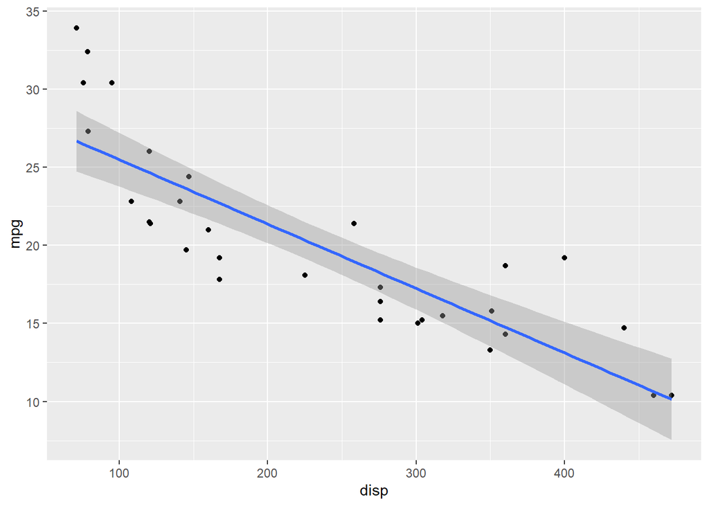

```r
g1 <- ggplot(mtcars, aes(y = mpg, x = disp)) +
geom_point()+geom_smooth(method = "lm")
g1
```

También, podemos mudar los colores de los pontos y de la recta.

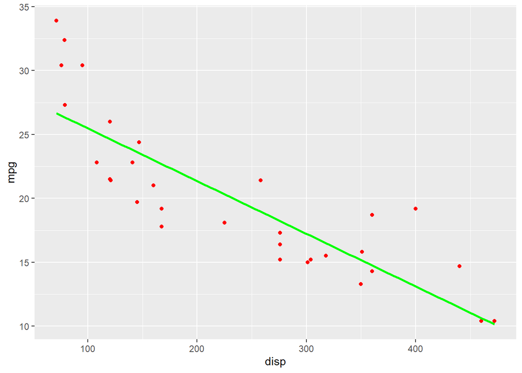

```r
g3 <- ggplot(mtcars, aes(y = mpg, x = disp)) +
geom_point(color = 'red')+geom_smooth(se = FALSE, method = "lm",color='green')
g3
```

Además, tener diferentes colores para diferentes categorias de cilindros (variable cyl).

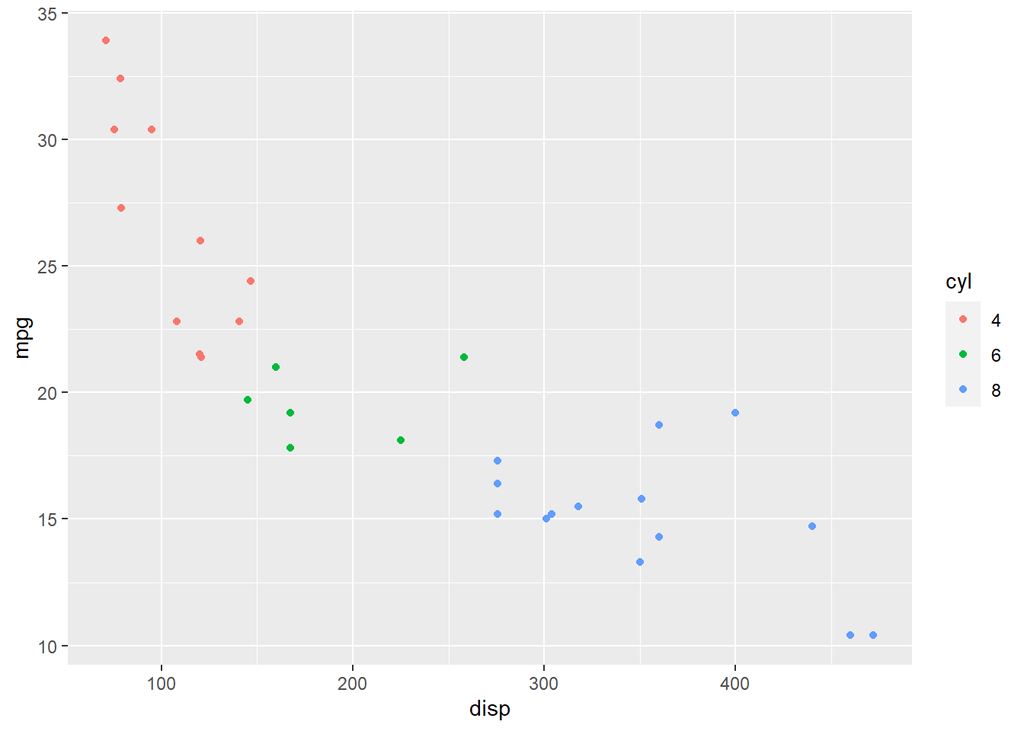

```r
mtcars$cyl=as.factor(mtcars$cyl)
g4 <- ggplot(mtcars, aes(y = mpg, x = disp)) +
geom_point(aes(color=cyl))
g4
```

O diferentes formas para diferentes categorias de cilindros (grupos)

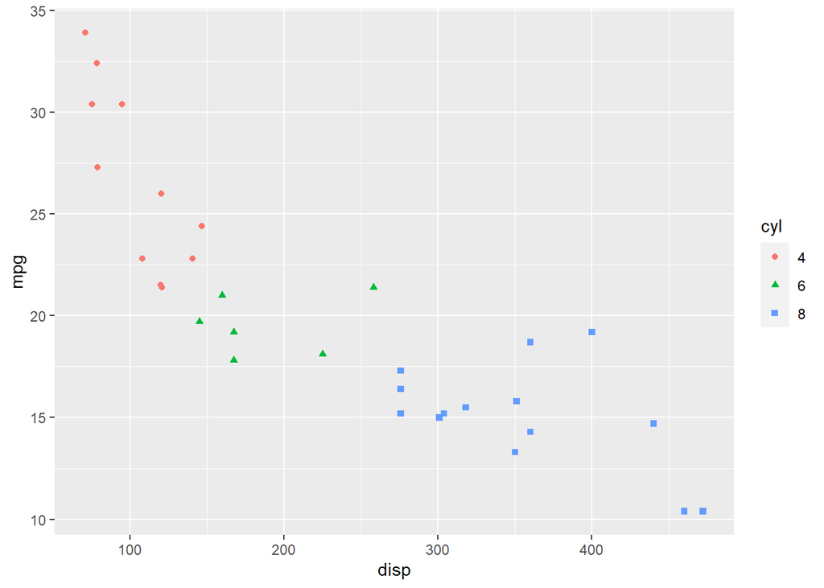

```r
g5 <- ggplot(mtcars, aes(y = mpg, x = disp)) +
geom_point(aes(shape = cyl, color=cyl))
g5
```

También, es posible modificar la forma y el tamaño del punto

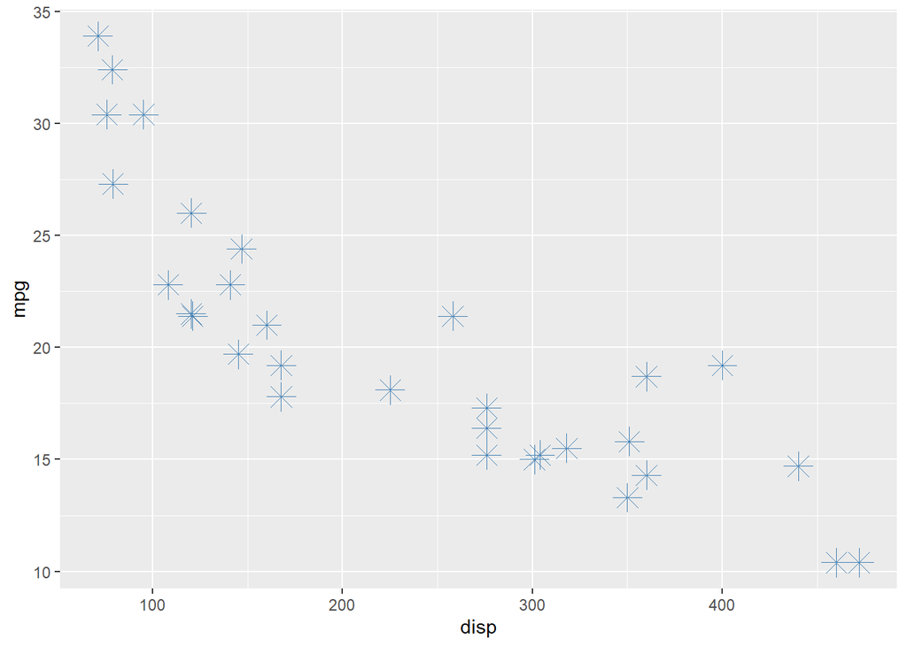

```r
g6 <- ggplot(mtcars, aes(y = mpg, x = disp)) +
geom_point(shape=8, color='steelblue', size=5)
g6
```

y cambiar el llenado de la figura usando fill:

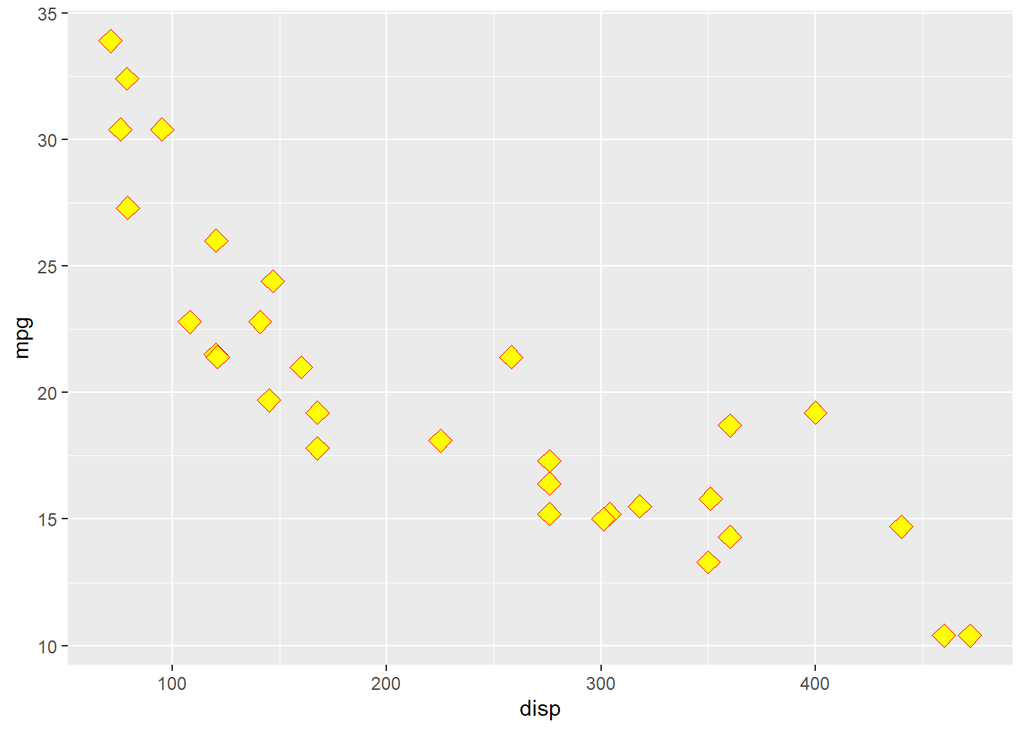

```r
g7 <- ggplot(mtcars, aes(y = mpg, x = disp)) +
geom_point(shape=23, fill = "yellow", color='red', size=4)
g7
```